# Ensemble Models - Regression

Ensemble methods improve prediction accuracy by combining the outputs of multiple base models. Bagging (Bootstrap Aggregation) reduces variance by averaging over bootstrapped trees (e.g., Random Forests), while Boosting sequentially builds trees that correct previous errors to reduce bias (e.g., Gradient Boosting).

### Strengths

- Excellent predictive performance
- Reduces variance and bias depending on method
- Handles large and high-dimensional datasets well
- Variable importance measures are available

### Weaknesses

- Models are harder to interpret
- Computationally intensive
- Requires careful tuning of model hyperparameters

### Overview

In this note, we examine voting models, bag, random forest, and various boosting models. Next, we tune hyperparameters for these models. All these models are designed to address regression problems.

## House Sales

The data contains characteristics of houses and sales price for over 20,000 houses in the Seattle area (King County, WA) from May 2014 to May 2015. The goal of this assignment is to select useful features to use for prediction.

##### Variables

- id: Sales ID
- price: Sale price
- bedrooms: Number of bedrooms
- bathrooms: Number of bathrooms
- sqft_living: Area (in square feet) of the living area
- sqft_lot: Area (in square feet) of the land house is on
- floors: Number of floors (levels) in house
- waterfront: Whether the house has a view of the waterfront (0: No, 1: Yes)
- view: Rating of quality fo view (0-4)
- condition: Condition of the house (1-5, higher number indicates better condition)
- grade: Grade given to the housing unit, based on King County grading system (1-13, higher number indicates better grade)
- sqft_above: Area (in square feet) apart from basement
- sqft_basement: Area (in square feet) of the basement
- yr_built: Year the house was built
- yr_renovated: Year when house was renovated
- age: Age of house in years at time of sale

### Read Data

- Import data
- Separate Features from the Outcome, click

```python
import numpy as np
import pandas as pd
import matplotlib.pyplot as plt

from sklearn.model_selection import train_test_split
from sklearn.metrics import root_mean_squared_error, r2_score
from sklearn.tree import DecisionTreeRegressor
```

```python
houses = pd.read_csv('houses.csv')
houses.head()
```

|  | id | price | bedrooms | bathrooms | sqft_living | sqft_lot | floors | waterfront | view | condition | grade | sqft_above | sqft_basement | yr_built | yr_renovated | age |
| --- | --- | --- | --- | --- | --- | --- | --- | --- | --- | --- | --- | --- | --- | --- | --- | --- |
| 0 | 7129300520 | 221900.0 | 3 | 1.00 | 1180 | 5650 | 1.0 | 0 | 0 | 3 | 7 | 1180 | 0 | 1955 | 0 | 59 |
| 1 | 6414100192 | 538000.0 | 3 | 2.25 | 2570 | 7242 | 2.0 | 0 | 0 | 3 | 7 | 2170 | 400 | 1951 | 1991 | 63 |
| 2 | 5631500400 | 180000.0 | 2 | 1.00 | 770 | 10000 | 1.0 | 0 | 0 | 3 | 6 | 770 | 0 | 1933 | 0 | 82 |
| 3 | 2487200875 | 604000.0 | 4 | 3.00 | 1960 | 5000 | 1.0 | 0 | 0 | 5 | 7 | 1050 | 910 | 1965 | 0 | 49 |
| 4 | 1954400510 | 510000.0 | 3 | 2.00 | 1680 | 8080 | 1.0 | 0 | 0 | 3 | 8 | 1680 | 0 | 1987 | 0 | 28 |

```python
X = houses.drop(['id','price','yr_built','yr_renovated'], axis = 1)
y = houses.price
```

### Split Data

- Split the data into train and test, placing 30% in the test sample
- Using stratified sampling based on binned values of the outcome

```python
y_binned = pd.qcut(y, q=20)
X_train, X_test, y_train, y_test = train_test_split(X,y,
                                                    test_size=0.3,
                                                    random_state=617,
                                                    stratify=y_binned)
```

## Ensemble Model

An ensemble model predictions of multiple individual models to produce a final prediction that is typically more accurate, robust, and stable than any single model. It works best when models are diverse, and predictions are independent and uncorrelated.

### Fit Individual Models

```python
from sklearn.tree import DecisionTreeRegressor
from sklearn.linear_model import LinearRegression
from sklearn.ensemble import VotingRegressor

reg = LinearRegression()
reg.fit(X_train, y_train)

tree = DecisionTreeRegressor(random_state=617)
tree.fit(X_train, y_train)
```

```
DecisionTreeRegressor(random_state=617)
```

### Performance

```python
models = [('Linear Regression',reg),
              ('Regression Tree',tree)]

for model_name, model in models:
    model.fit(X_train, y_train)
    pred_test = model.predict(X_test)
    rmse = root_mean_squared_error(y_test, pred_test)
    print(model_name, rmse)
```

```
Linear Regression 218930.99331410025
Regression Tree 269138.06694233755
```

### Combine Models

For regression problems, predictions are aggregated by averaging.

```python
vc = VotingRegressor(estimators=models)
vc.fit(X_train, y_train)
pred_train = vc.predict(X_train)
pred_test = vc.predict(X_test)
```

```python
print('Train RMSE: ', root_mean_squared_error(y_train, pred_train))
print('Test RMSE:  ', root_mean_squared_error(y_test, pred_test))
```

```
Train RMSE:  107829.28273583231
Test RMSE:   219044.94791252134
```

## Bag

A bag model, short for Bootstrap Aggregating, aims to improve the stability and accuracy of predictions by fitting multiple models in parallel on random subsets of the data and then aggregating their predictions.

### with tree estimator

```python
%%time
from sklearn.ensemble import BaggingRegressor
bag = BaggingRegressor(n_estimators=200,
                        n_jobs = -1,
                        oob_score=True,
                        random_state=1031) # default estimator is DecisionTreeRegressor
bag.fit(X_train, y_train)
```

```
CPU times: total: 4.31 s
Wall time: 1min 2s
```

```
BaggingRegressor(n_estimators=200, n_jobs=-1, oob_score=True, random_state=1031)
```

### Predict

Predictions of individual models are combined by averaging.

```python
pred_train = bag.predict(X_train)
pred_test = bag.predict(X_test)
```

### Evaluate

```python
print('Train RMSE: ', root_mean_squared_error(y_train, pred_train))
print('Test RMSE:  ', root_mean_squared_error(y_test, pred_test))
```

```
Train RMSE:  71330.1883538567
Test RMSE:   194798.81646852565
```

## Bag

### with Regression estimator

```python
from sklearn.linear_model import LinearRegression
reg = LinearRegression()

bag = BaggingRegressor(estimator = reg,
                        n_estimators=200,
                        n_jobs = -1,
                        oob_score=True,
                        random_state=1031)
bag.fit(X_train, y_train)
```

```
BaggingRegressor(estimator=LinearRegression(), n_estimators=200, n_jobs=-1,
                 oob_score=True, random_state=1031)
```

### Predict

```python
pred_train = bag.predict(X_train)
pred_test = bag.predict(X_test)
```

### Evaluate

```python
print('Train RMSE: ', root_mean_squared_error(y_train, pred_train))
print('Test RMSE:  ', root_mean_squared_error(y_test, pred_test))
```

```
Train RMSE:  215603.46463559326
Test RMSE:   218823.6382373206
```

R2 values for train, test and out-of-bag samples

```python
print('Train R2: ', r2_score(y_train, pred_train))
print('Test R2:  ', r2_score(y_test, pred_test))
print('Out of Bag Error: ', bag.oob_score_)
```

```
Train R2:  0.6584754160516704
Test R2:   0.6363164660998932
Out of Bag Error:  0.6563338170188646
```

## Random Forest

A Random Forest upon the concept of bagging (bootstrap aggregating) by training multiple decision trees on different random subsets of the data and features, and then combining their predictions to make a final decision. So, it is a special type of bag model that uses a random subset of features for each tree.

### with tree estimator

```python
%%time
from sklearn.ensemble import RandomForestRegressor
forest = RandomForestRegressor(n_estimators=200,
                                n_jobs = -1,
                                oob_score=True,
                                random_state=1031)
forest.fit(X_train, y_train)
```

```
CPU times: total: 26.2 s
Wall time: 3.86 s
```

```
RandomForestRegressor(n_estimators=200, n_jobs=-1, oob_score=True,
                      random_state=1031)
```

### Predict

```python
pred_train = forest.predict(X_train)
pred_test = forest.predict(X_test)
```

### Evaluate

```python
print('Train RMSE: ', root_mean_squared_error(y_train, pred_train))
print('Test RMSE:  ', root_mean_squared_error(y_test, pred_test))
```

```
Train RMSE:  71115.97661526348
Test RMSE:   195337.52455050955
```

```python
print('Train R2: ', r2_score(y_train, pred_train))
print('Test R2:  ', r2_score(y_test, pred_test))
print('Out of Bag Error: ', bag.oob_score_)
```

```
Train R2:  0.9628426394189731
Test R2:   0.7101945630083957
Out of Bag Error:  0.6563338170188646
```

### Feature Importance

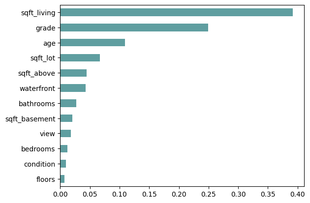

```python
pd.Series(forest.feature_importances_, index=X_train.columns)\
.sort_values(ascending=True)\
.plot(kind = 'barh', color = 'cadetblue')
plt.show()
```

## Boosting

A boosting model combines the predictions of multiple weak learners (typically shallow decision trees) to form a strong predictive model. Boosting works by training models sequentially, where each new model is trained to correct the errors made by the previous models.

## Adaboost

AdaBoost, short for Adaptive Boosting, is one of the earliest and most well-known boosting algorithms in machine learning. It builds a strong classifier by sequentially combining multiple weak learners, typically decision stumps (trees with only one split). Each subsequent model is trained by placing more emphasis (weight) on the instances that were misclassified by previous models.

### with Tree Estimator

```python
from sklearn.ensemble import AdaBoostRegressor
adaboost = AdaBoostRegressor(n_estimators = 100,
                              random_state = 1031)
adaboost.fit(X_train, y_train)
```

```
AdaBoostRegressor(n_estimators=100, random_state=1031)
```

### Predict

```python
pred_train = adaboost.predict(X_train)
pred_test = adaboost.predict(X_test)
```

### Evaluate

```python
print('Train RMSE: ', root_mean_squared_error(y_train, pred_train))
print('Test RMSE:  ', root_mean_squared_error(y_test, pred_test))
```

```
Train RMSE:  373315.3673588364
Test RMSE:   378555.2970207804
```

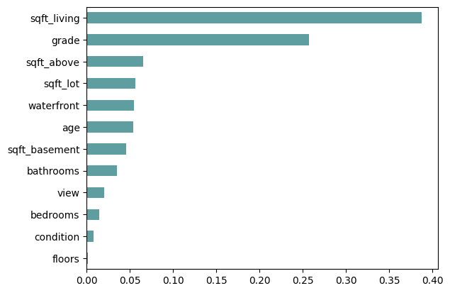

```python
pd.Series(adaboost.feature_importances_, index=X_train.columns)\
    .sort_values(ascending=True)\
    .plot(kind = 'barh', color = 'cadetblue')
plt.show()
```

## Gradient Boosting

Gradient Boosting builds a strong predictive model by sequentially adding weak learners (typically shallow decision trees), where each new learner is trained to minimize the error of the current ensemble using gradient descent. Unlike AdaBoost, which reweights observations, Gradient Boosting fits new models to the residual errors (the differences between actual and predicted values) by optimizing a loss function using gradients — hence the name “gradient” boosting.

```python
%time
from sklearn.ensemble import GradientBoostingRegressor
gb = GradientBoostingRegressor(n_estimators = 100,
                                random_state = 1031)
gb.fit(X_train, y_train)
```

```
CPU times: total: 0 ns
Wall time: 6.44 μs
```

```
GradientBoostingRegressor(random_state=1031)
```

### Predict

```python
pred_train = gb.predict(X_train)
pred_test = gb.predict(X_test)
```

### Evaluate

```python
print('Train RMSE: ', root_mean_squared_error(y_train, pred_train))
print('Test RMSE:  ', root_mean_squared_error(y_test, pred_test))
```

```
Train RMSE:  171803.16573360295
Test RMSE:   194424.81715948644
```

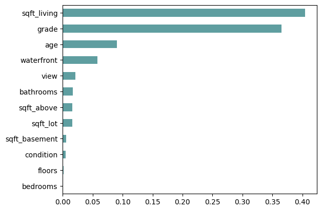

```python
pd.Series(gb.feature_importances_, index=X_train.columns)\
    .sort_values(ascending=True)\
    .plot(kind = 'barh', color = 'cadetblue')
plt.show()
```

## Stochastic Gradient Boosting

Stochastic Gradient Boosting is a variant of Gradient Boosting that introduces randomness into the boosting process to improve generalization and reduce overfitting.

In traditional gradient boosting, each weak learner is trained on the entire dataset to fit the residuals. In stochastic gradient boosting, each learner is instead trained on a random subsample of the data (typically without replacement). This makes the model more robust and faster, especially for large datasets.

```python
%%time
from sklearn.ensemble import GradientBoostingRegressor
sgb = GradientBoostingRegressor(n_estimators = 100,
                                 random_state = 617,
                                 max_features=0.2, # sample 20% of the features for each tree
                                 subsample=0.8)    # sample 80% of the data for each tree
sgb.fit(X_train, y_train)
```

```
CPU times: total: 484 ms
Wall time: 485 ms
```

```
GradientBoostingRegressor(max_features=0.2, random_state=617, subsample=0.8)
```

### Predict

```python
pred_train = sgb.predict(X_train)
pred_test = sgb.predict(X_test)
```

### Evaluate

```python
print('Train RMSE: ', root_mean_squared_error(y_train, pred_train))
print('Test RMSE:  ', root_mean_squared_error(y_test, pred_test))
```

```
Train RMSE:  177832.16047845123
Test RMSE:   201031.08060307268
```

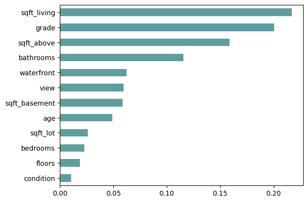

```python
pd.Series(sgb.feature_importances_, index=X_train.columns)\
    .sort_values(ascending=True)\
    .plot(kind = 'barh', color = 'cadetblue')
plt.show()
```

## Tuned Forest

### Model for Tuning

```python
from sklearn.ensemble import RandomForestRegressor
forest = RandomForestRegressor(n_estimators=200,
                        n_jobs = -1,
                        oob_score=True,
                        random_state=1031)
forest.get_params()
```

```
{'bootstrap': True,
 'ccp_alpha': 0.0,
 'criterion': 'squared_error',
 'max_depth': None,
 'max_features': 1.0,
 'max_leaf_nodes': None,
 'max_samples': None,
 'min_impurity_decrease': 0.0,
 'min_samples_leaf': 1,
 'min_samples_split': 2,
 'min_weight_fraction_leaf': 0.0,
 'monotonic_cst': None,
 'n_estimators': 200,
 'n_jobs': -1,
 'oob_score': True,
 'random_state': 1031,
 'verbose': 0,
 'warm_start': False}
```

### Tune

```python
%%time
from sklearn.model_selection import GridSearchCV
param_grid = {'n_estimators':[200,500,1000],
             'max_features': [1, 2, 3, 4, 5, 6, 7, 8, 9, 10, 12],
             'max_depth': [1, 2, 3, 4, 5, 6, 7, 8, 9, 10, 11, 12]}
tune_forest = GridSearchCV(estimator=forest,
                           param_grid=param_grid,
                           cv=5,
                           scoring ='neg_root_mean_squared_error',
                           verbose = 2,
                           n_jobs=-1)
tune_forest.fit(X_train, y_train)
```

```
Fitting 5 folds for each of 396 candidates, totalling 1980 fits
CPU times: total: 16.7 s
Wall time: 40min 18s
```

```
GridSearchCV(cv=5,
             estimator=RandomForestRegressor(n_estimators=200, n_jobs=-1,
                                             oob_score=True,
                                             random_state=1031),
             n_jobs=-1,
             param_grid={'max_depth': [1, 2, 3, 4, 5, 6, 7, 8, 9, 10, 11, 12],
                         'max_features': [1, 2, 3, 4, 5, 6, 7, 8, 9, 10, 12],
                         'n_estimators': [200, 500, 1000]},
             scoring='neg_root_mean_squared_error', verbose=2)
```

```python
tune_forest.best_params_
```

```
{'max_depth': 11, 'max_features': 7, 'n_estimators': 200}
```

```python
best_forest = tune_forest.best_estimator_
```

## Evaluate

```python
pred_train = best_forest.predict(X_train)
pred_test = best_forest.predict(X_test)

print('Train RMSE: ', root_mean_squared_error(y_train, pred_train))
print('Test RMSE:  ', root_mean_squared_error(y_test, pred_test))
```

```
Train RMSE:  133141.50426621875
Test RMSE:   192922.53162694685
```

## Tuned Stochastic Gradient Boost

### Model for Tuning

```python
from sklearn.ensemble import GradientBoostingRegressor
sgb = GradientBoostingRegressor(random_state = 1031)
```

### Tune

```python
%%time
from sklearn.model_selection import GridSearchCV
param_grid = {'n_estimators':[100],
              'learning_rate': [0.01, 0.02, 0.03, 0.05, 0.06, 0.07, 0.08, 0.09],
              'max_depth': [1,2,3,4,5] ,
              'subsample':[0.5,0.6,0.8,1],
              'max_features': [1,2,3,4]}
tune_boost = GridSearchCV(estimator=sgb,
                           param_grid=param_grid,
                           cv=5,
                           scoring ='neg_root_mean_squared_error',
                           verbose = 4,
                           n_jobs=-1)
tune_boost.fit(X_train, y_train)
```

```
Fitting 5 folds for each of 640 candidates, totalling 3200 fits
CPU times: total: 15.8 s
Wall time: 3min 15s
```

```
GridSearchCV(cv=5, estimator=GradientBoostingRegressor(random_state=1031),
             n_jobs=-1,
             param_grid={'learning_rate': [0.01, 0.02, 0.03, 0.05, 0.06, 0.07,
                                           0.08, 0.09],
                         'max_depth': [1, 2, 3, 4, 5],
                         'max_features': [1, 2, 3, 4], 'n_estimators': [100],
                         'subsample': [0.5, 0.6, 0.8, 1]},
             scoring='neg_root_mean_squared_error', verbose=4)
```

```python
pd.DataFrame(tune_boost.cv_results_).head()
```

|  | mean_fit_time | std_fit_time | mean_score_time | std_score_time | param_learning_rate | param_max_depth | param_max_features | param_n_estimators | param_subsample | params | split0_test_score | split1_test_score | split2_test_score | split3_test_score | split4_test_score | mean_test_score | std_test_score | rank_test_score |
| --- | --- | --- | --- | --- | --- | --- | --- | --- | --- | --- | --- | --- | --- | --- | --- | --- | --- | --- |
| 0 | 0.416559 | 0.209058 | 0.004493 | 0.000219 | 0.01 | 1 | 1 | 100 | 0.5 | {'learning_rate': 0.01, 'max_depth': 1, 'max_f... | -350762.237063 | -330260.293791 | -297512.057565 | -343141.266513 | -310130.483264 | -326361.267639 | 19939.374911 | 637 |
| 1 | 0.404790 | 0.115085 | 0.004042 | 0.000141 | 0.01 | 1 | 1 | 100 | 0.6 | {'learning_rate': 0.01, 'max_depth': 1, 'max_f... | -350831.374050 | -330813.126730 | -297695.695121 | -343361.153333 | -310072.685706 | -326554.806988 | 19972.215363 | 639 |
| 2 | 0.376897 | 0.124108 | 0.004190 | 0.000169 | 0.01 | 1 | 1 | 100 | 0.8 | {'learning_rate': 0.01, 'max_depth': 1, 'max_f... | -350803.623562 | -330293.115760 | -297521.937712 | -343177.378364 | -310037.607476 | -326366.732575 | 19969.168511 | 638 |
| 3 | 0.267151 | 0.091348 | 0.004398 | 0.000080 | 0.01 | 1 | 1 | 100 | 1.0 | {'learning_rate': 0.01, 'max_depth': 1, 'max_f... | -352508.148558 | -331701.377737 | -298937.369903 | -344871.710158 | -310825.422193 | -327768.805710 | 20190.787422 | 640 |
| 4 | 0.252716 | 0.002326 | 0.003906 | 0.000103 | 0.01 | 1 | 2 | 100 | 0.5 | {'learning_rate': 0.01, 'max_depth': 1, 'max_f... | -338067.208802 | -317032.936655 | -284906.668492 | -330440.985497 | -296363.990005 | -313362.357890 | 20070.640736 | 635 |

```python
tune_boost.best_params_
```

```
{'learning_rate': 0.09,
 'max_depth': 5,
 'max_features': 4,
 'n_estimators': 100,
 'subsample': 1}
```

[figure not shown]

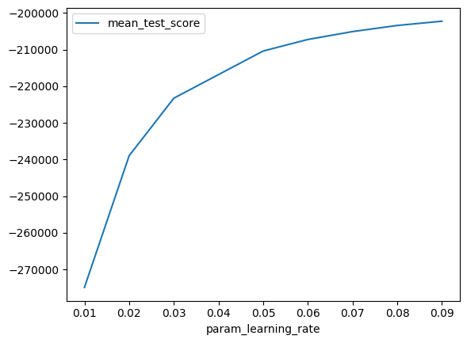

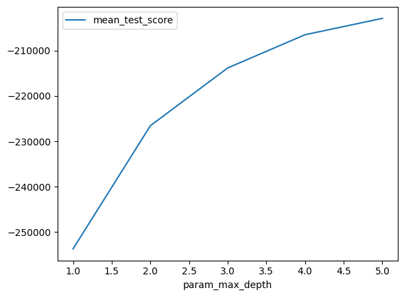

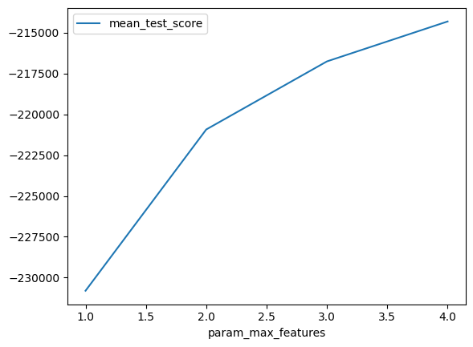

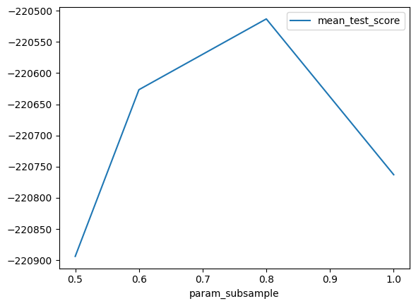

```python
cv_values = pd.DataFrame(tune_boost.cv_results_)
cv_values[['param_n_estimators', 'mean_test_score']].groupby('param_n_estimators').mean().plot()
cv_values[['param_learning_rate', 'mean_test_score']].groupby('param_learning_rate').mean().plot()
cv_values[['param_max_depth', 'mean_test_score']].groupby('param_max_depth').mean().plot()
cv_values[['param_max_features', 'mean_test_score']].groupby('param_max_features').mean().plot()
cv_values[['param_subsample', 'mean_test_score']].groupby('param_subsample').mean().plot()
plt.show()
```

```python
cv_values[['param_n_estimators','param_learning_rate','param_max_depth','param_max_features','param_subsample','mean_test_score']].\
sort_values('mean_test_score', ascending=False).head(15)
```

|  | param_n_estimators | param_learning_rate | param_max_depth | param_max_features | param_subsample | mean_test_score |
| --- | --- | --- | --- | --- | --- | --- |
| 639 | 100 | 0.09 | 5 | 4 | 1.0 | -187697.761734 |
| 559 | 100 | 0.08 | 5 | 4 | 1.0 | -187838.608434 |
| 479 | 100 | 0.07 | 5 | 4 | 1.0 | -188052.258811 |
| 623 | 100 | 0.09 | 4 | 4 | 1.0 | -188487.747966 |
| 553 | 100 | 0.08 | 5 | 3 | 0.6 | -188843.347133 |
| 635 | 100 | 0.09 | 5 | 3 | 1.0 | -188847.454661 |
| 542 | 100 | 0.08 | 4 | 4 | 0.8 | -188927.428093 |
| 463 | 100 | 0.07 | 4 | 4 | 1.0 | -189106.063153 |
| 475 | 100 | 0.07 | 5 | 3 | 1.0 | -189140.405085 |
| 555 | 100 | 0.08 | 5 | 3 | 1.0 | -189157.869394 |
| 399 | 100 | 0.06 | 5 | 4 | 1.0 | -189334.927572 |
| 637 | 100 | 0.09 | 5 | 4 | 0.6 | -189351.997668 |
| 622 | 100 | 0.09 | 4 | 4 | 0.8 | -189357.736887 |
| 395 | 100 | 0.06 | 5 | 3 | 1.0 | -189395.086024 |
| 541 | 100 | 0.08 | 4 | 4 | 0.6 | -189432.930458 |

```python
best_boost = tune_boost.best_estimator_
```

#### Variable Importance

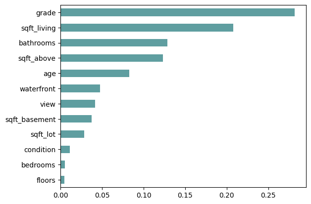

```python
pd.Series(best_boost.feature_importances_, index=X_train.columns)\
    .sort_values(ascending=True)\
    .plot(kind = 'barh', color = 'cadetblue')
plt.show()
```

### Evaluate

```python
pred_train = best_boost.predict(X_train)
pred_test = best_boost.predict(X_test)

print('Train RMSE: ', root_mean_squared_error(y_train, pred_train))
print('Test RMSE:  ', root_mean_squared_error(y_test, pred_test))
```

```
Train RMSE:  152419.6974131321
Test RMSE:   191375.8700865698
```

## Summary

```python
import platform
from IPython.display import display, HTML
import matplotlib
import sklearn as sklearn_complete
text = ('This file was generated using Python ' + platform.python_version() +\
      ' on a ' + platform.platform() + \
      ' system with Pandas ' + pd.__version__ + \
      ', Numpy ' + np.__version__ + \
      ', Matplotlib ' + matplotlib.__version__ + \
      ', Scikit-Learn ' + sklearn_complete.__version__ )

html = f"""
<hr style="border: 0; height: 1px; background: lightgray;" />
<p style="font-size: x-small; color: #555;">{text}</p>
"""

display(HTML(html))
```

This file was generated using Python 3.13.5 on a Windows-10-10.0.19045-SP0 system with Pandas 2.3.0, Numpy 2.3.1, Matplotlib 3.10.3, Scikit-Learn 1.7.1